# 804919177_stats102a_hw1

David Collier

January 18, 2020

```r
#source my R script file
source("804919177_stats102A_hw1.R")
```

## 1. Greatest Common Divisor

# gcd() Flowchart

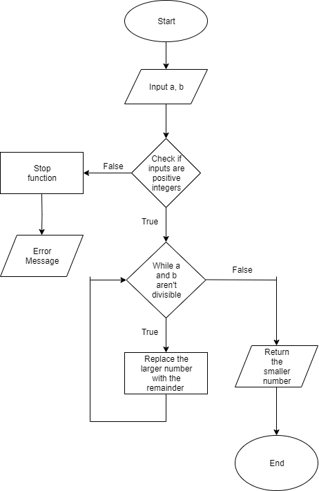

gcd() Flowchart

# gcd() Pseudocode

Check the inputs for validity and throw an error if either is not a positive integer.  
While the two numbers are not divisible by each other,  
replace the larger of the two numbers with the remainder after dividing the two numbers.  
Repeat this until the new two numbers are divisible by each other.  
Once the two numbers are divisible, the smaller number is the gcd, so return that number.

# gcd_three() Flowchart

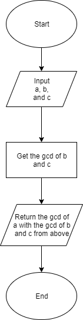

gcd_three() Flowchart

# gcd_three() Pseudocode

Take the gcd of two of the 3 integers using the gcd function.  
Take the gcd of the third integer with the gcd of the first two integers, and return that number.

## 2. Prime Factorization

# get_factors() Flowchart

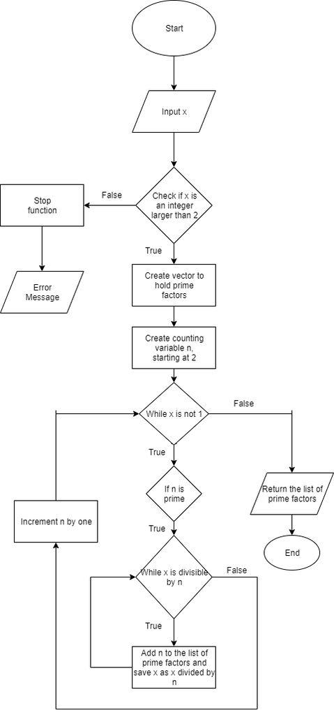

get_factors() Flowchart

# Pseudocode

Check the input to make sure it is an integer larger than two.  
Check if the input is divisible by increasingly large primes -  
if it is divisible, divide the input by that prime and save that prime as a prime factor, then continuing dividing the now smaller input by larger primes  
Once the input is reduced to 1, you have the complete list of prime factors.

# is_prime() Flowchart

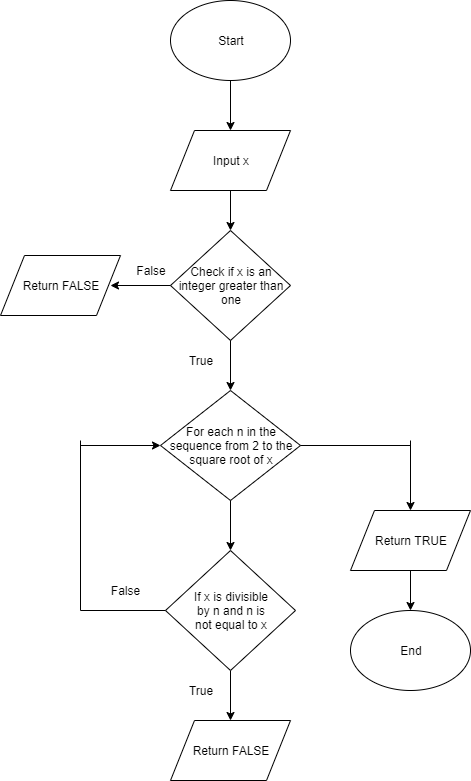

is_prime() Flowchart

# is_prime() Pseudocode

If the input is less than two or not an integer, it is not prime.  
Check if the input is divisible by an integer between 2 and its square root  
If the input is divisible, it is not prime  
Otherwise, it is prime

# 1. gcd function

```r
gcd(1071, 462)
```

```
## [1] 21
```

```r
gcd(462, 1071)
```

```
## [1] 21
```

```r
gcd(646, 1406)
```

```
## [1] 38
```

```r
gcd(1, 10)
```

```
## [1] 1
```

```r
try(gcd(0, 12))
```

```
## Error in gcd(0, 12) : ERROR: inputs must be positive integers
```

```r
try(gcd(4.5, 12))
```

```
## Error in gcd(4.5, 12) : ERROR: inputs must be positive integers
```

```r
try(gcd(-1, 12))
```

```
## Error in gcd(-1, 12) : ERROR: inputs must be positive integers
```

# 2. gcd_three function

```r
gcd_three(1071, 462, 4452)
```

```
## [1] 21
```

```r
gcd_three(646, 1406, 4218)
```

```
## [1] 38
```

# 3. is_prime helper function

```r
is_prime(4)
```

```
## [1] FALSE
```

```r
is_prime(c(2, 97, 23, 51, 119, -1, 0, 1.5))
```

```
## [1]  TRUE  TRUE  TRUE FALSE FALSE FALSE FALSE FALSE
```

# 4. get_factors function

```r
get_factors(12)
```

```
## [1] 2 2 3
```

```r
get_factors(1800)
```

```
## [1] 2 2 2 3 3 5 5
```

```r
get_factors(32851)
```

```
## [1]  7 13 19 19
```

```r
get_factors(9587)
```

```
## [1] 9587
```

```r
try(get_factors(-280))
```

```
## Error in get_factors(-280) :
##   ERROR: input must be an integer greater than 1
```

```r
try(get_factors(280.75))
```

```
## Error in get_factors(280.75) :
##   ERROR: input must be an integer greater than 1
```

```r
#Generic test for get_factors()
x <- sample(x = 1e4, size = 1)
y <- get_factors(x)
this_works <- prod(y) == x & all(is_prime(y))
this_works
```

```
## [1] TRUE
```